# Basic GLMs in R

# GLM notation, and a slightly more complex example

So far we have only looked at modelling one predictor and one response variable. What if we want to look at multiple variables, with interactions?

In modeling formulae, you will often find these symbols:

Plus (+) inclusion of a variable into the model. This makes for an **additive** model

Asterisk (*) or colon (:) inclusion of a variable, and its interactions. This makes for a **multiplicative/interaction** model.

For example:

**larvae ~ female_mass + female_length** means that we want to model how the number of larvae are affected individually by female mass **AND** length (i.e. the effect of female mass on larval output does not depend on the effect of female length)

**larvae ~ female_mass * female_length** means that we want to look at how both female mass and length individually affect the number of larvae produced, **AND** whether female mass depends on female length, and vice-versa. A better way of writing this formula is:  
**larvae ~ female_mass + female_length + female_mass:female_length**

Let’s look at an example where we are interested in looking at the effect of soil pH (categorical variable; low, mid, and high) and biomass (continuous variable) on the number of species recorded on plots of land. This was taken from the R Book, by Michael Crawley.

```r
plant.species.data <- read.table ("data/therbook/species.txt", header = TRUE)
head(plant.species.data)
```

```
##     pH   Biomass Species
## 1 high 0.4692972      30
## 2 high 1.7308704      39
## 3 high 2.0897785      44
## 4 high 3.9257871      35
## 5 high 4.3667927      25
## 6 high 5.4819747      29
```

```r
# make pH levels a factor, and force the order we want. Otherwise R orders
# them alphabetically
plant.species.data$pH = factor(plant.species.data$pH,
                                  levels = c("low", "mid", "high"))
str(plant.species.data)
```

```
## 'data.frame':    90 obs. of  3 variables:
##  $ pH     : Factor w/ 3 levels "low","mid","high": 3 3 3 3 3 3 3 3 3 3 ...
##  $ Biomass: num  0.469 1.731 2.09 3.926 4.367 ...
##  $ Species: int  30 39 44 35 25 29 23 18 19 12 ...
```

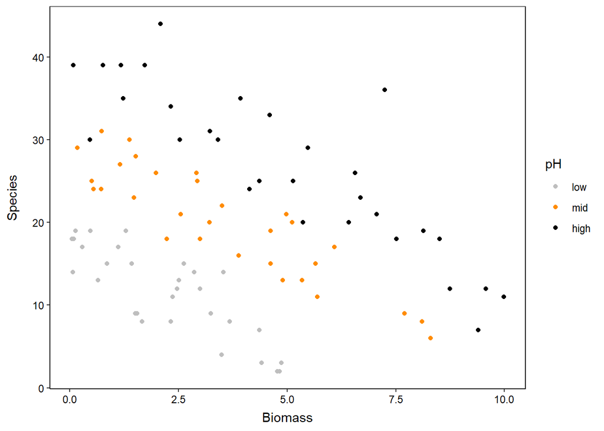

```r
# Plot -> we can already see a negative relationship
ggplot2::ggplot(data = plant.species.data,
                aes(x = Biomass, y = Species,
                    colour = pH), alpha = 0.7 ) +
  scale_colour_manual(values = c("grey", "darkorange", "black")) +
  geom_point() +
  theme(legend.position = "right")
```

```r
# if you want to plot just one pH group, use dplyr to filter the data:
# dplyr::filter(plant.species.data, pH == "high")

# Let's run a Poisson GLM, since we are dealing with species counts
# Here, we will just model biomass as a predictor
plant.glm.1 = glmmTMB::glmmTMB(Species ~ Biomass,
                               data = plant.species.data,
                               family = poisson)

summary(plant.glm.1)
```

```
##  Family: poisson  ( log )
## Formula:          Species ~ Biomass
## Data: plant.species.data
##
##      AIC      BIC   logLik deviance df.resid
##    830.9    835.9   -413.4    826.9       88
##
##
## Conditional model:
##              Estimate Std. Error z value Pr(>|z|)
## (Intercept)  3.184094   0.039159   81.31  < 2e-16 ***
## Biomass     -0.064441   0.009838   -6.55 5.74e-11 ***
## ---
## Signif. codes:  0 '***' 0.001 '**' 0.01 '*' 0.05 '.' 0.1 ' ' 1
```

```r
# Let's add pH in as well
plant.glm.2 = glmmTMB::glmmTMB(Species ~ Biomass + pH,
                               data = plant.species.data,
                               family = poisson)

# if we compare model 1 and 2, model 2 is a significantly better fit. I.e.
# pH has a significant effect on species numbers
anova(plant.glm.1, plant.glm.2, test = "Chisq")
```

```
## Data: plant.species.data
## Models:
## plant.glm.1: Species ~ Biomass, zi=~0, disp=~1
## plant.glm.2: Species ~ Biomass + pH, zi=~0, disp=~1
##             Df    AIC    BIC  logLik deviance  Chisq Chi Df Pr(>Chisq)
## plant.glm.1  2 830.86 835.86 -413.43   826.86
## plant.glm.2  4 526.43 536.43 -259.22   518.43 308.43      2  < 2.2e-16 ***
## ---
## Signif. codes:  0 '***' 0.001 '**' 0.01 '*' 0.05 '.' 0.1 ' ' 1
```

```r
# And now let's introduce an interaction between biomass and pH
plant.glm.3 = glmmTMB::glmmTMB(Species ~ Biomass + pH + Biomass:pH,
                               data = plant.species.data,
                               family = poisson)

# compare model 2 and 3: the interaction between
# biomass and pH has a significant effect on species numbers on the plots,
# since model 3 performs significantly better than model 2
anova(plant.glm.2, plant.glm.3, test = "Chisq", type = "III")
```

```
## Data: plant.species.data
## Models:
## plant.glm.2: Species ~ Biomass + pH, zi=~0, disp=~1
## plant.glm.3: Species ~ Biomass + pH + Biomass:pH, zi=~0, disp=~1
##             Df    AIC    BIC  logLik deviance Chisq Chi Df Pr(>Chisq)
## plant.glm.2  4 526.43 536.43 -259.22   518.43
## plant.glm.3  6 514.39 529.39 -251.20   502.39 16.04      2  0.0003288 ***
## ---
## Signif. codes:  0 '***' 0.001 '**' 0.01 '*' 0.05 '.' 0.1 ' ' 1
```

```r
# let's run a Likelihood Ratio Test (LRT) on our ADDITIVE model
# here we see that both biomass and pH have a significant effect on the number
# of species recorded
# we assume here that the relationship between biomass and species number is
# the same across all three pH levels
car::Anova(plant.glm.2, test.statistic = "Chisq", type = "III")
```

```
## Analysis of Deviance Table (Type III Wald chisquare tests)
##
## Response: Species
##               Chisq Df Pr(>Chisq)
## (Intercept) 2254.25  1  < 2.2e-16 ***
## Biomass      158.23  1  < 2.2e-16 ***
## pH           288.64  2  < 2.2e-16 ***
## ---
## Signif. codes:  0 '***' 0.001 '**' 0.01 '*' 0.05 '.' 0.1 ' ' 1
```

```r
# let's run a LRT on the MULTIPLICATIVE model
# here, we see a significant interaction between biomass and pH
# this means that the effect of biomass on species number differs between
# the three pH levels
# here, we see that the effect of biomass (our predictor variable)
# on species number (response variable) is allowed to vary across pH levels
car::Anova(plant.glm.3, test.statistic = "Chisq", type = "III")
```

```
## Analysis of Deviance Table (Type III Wald chisquare tests)
##
## Response: Species
##                Chisq Df Pr(>Chisq)
## (Intercept) 1284.004  1  < 2.2e-16 ***
## Biomass       47.511  1  5.470e-12 ***
## pH            63.115  2  1.971e-14 ***
## Biomass:pH    15.543  2  0.0004216 ***
## ---
## Signif. codes:  0 '***' 0.001 '**' 0.01 '*' 0.05 '.' 0.1 ' ' 1
```

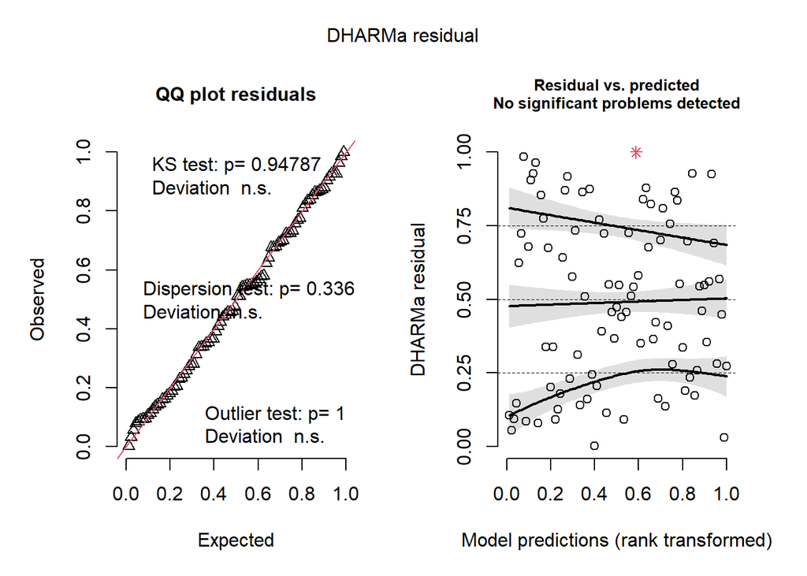

```r
# model diagnostics
plot(DHARMa::simulateResiduals(plant.glm.3) )
```

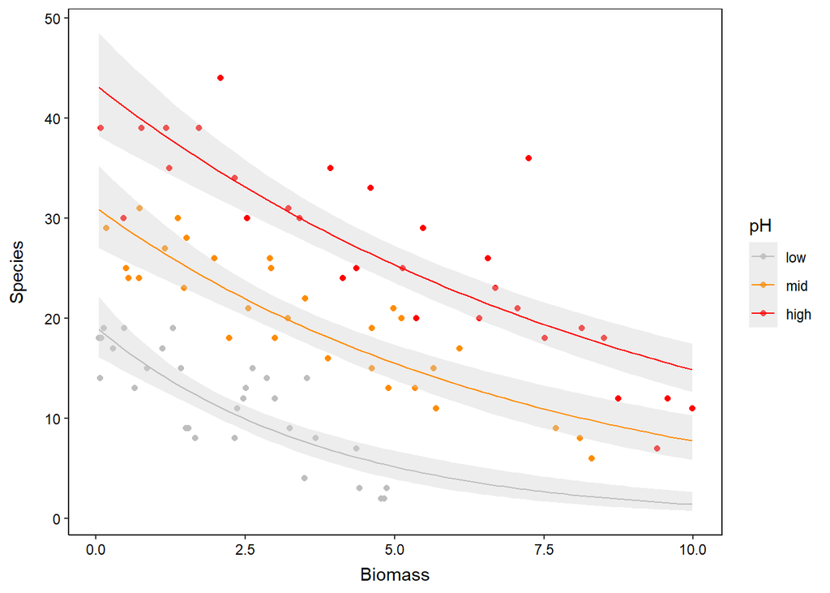

```r
# plot the fitted model
# looks like a good model to use!
ggplot2::ggplot(data = plant.species.data,
                aes(x = Biomass, y = Species,
                    colour = pH), alpha = 0.7 ) +
  scale_colour_manual(values = c("grey", "darkorange", "red")) +
  geom_point() +
  geom_smooth(method = "glm", method.args = list(family = "poisson"),
              fill = "lightgrey", linewidth = 0.5, fullrange = TRUE) +
  theme(legend.position = "right")
```

What can you conclude from this plot? Our LR test on model 3 suggests that biomass ($\chi^2$ = 47.5, d.f. = 1, p < 0.001), pH ($\chi^2$ = 63.1, d.f. = 2, p < 0.001), and the effect of biomass on species number across pH levels($\chi^2$ = 15.5, d.f. = 2, p < 0.001) were all significant.

Let’s have a look at the summary output for our third (interaction) GLM:

```r
summary(plant.glm.3)
```

```
##  Family: poisson  ( log )
## Formula:          Species ~ Biomass + pH + Biomass:pH
## Data: plant.species.data
##
##      AIC      BIC   logLik deviance df.resid
##    514.4    529.4   -251.2    502.4       84
##
##
## Conditional model:
##                Estimate Std. Error z value Pr(>|z|)
## (Intercept)     2.95255    0.08240   35.83  < 2e-16 ***
## Biomass        -0.26216    0.03803   -6.89 5.47e-12 ***
## pHmid           0.48411    0.10723    4.51 6.34e-06 ***
## pHhigh          0.81557    0.10284    7.93 2.18e-15 ***
## Biomass:pHmid   0.12314    0.04270    2.88 0.003927 **
## Biomass:pHhigh  0.15503    0.04003    3.87 0.000108 ***
## ---
## Signif. codes:  0 '***' 0.001 '**' 0.01 '*' 0.05 '.' 0.1 ' ' 1
```

```r
# another way of presenting the output:
gtsummary::tbl_regression(plant.glm.3, exponentiate = TRUE)
```

| **Characteristic** | **exp(Beta)** | **95% CI**<sup>1</sup> | **p-value** |
| --- | --- | --- | --- |
| Biomass | 0.77 | 0.71, 0.83 | <0.001 |
| pH |  |  |  |
| low | — | — |  |
| mid | 1.62 | 1.32, 2.00 | <0.001 |
| high | 2.26 | 1.85, 2.77 | <0.001 |
| Biomass * pH |  |  |  |
| Biomass * mid | 1.13 | 1.04, 1.23 | 0.004 |
| Biomass * high | 1.17 | 1.08, 1.26 | <0.001 |

<sup>1</sup> CI = Confidence Interval

The **Biomass:pHmid** value of **0.12314** means that a one unit increase in biomass in the pH mid group will result in an increase in species richness by a factor of 1.13 (**exp(0.12314)**) more than the pH low group. Similarly, the value of **0.15503** in the **Biomass:pHhigh** means that a one unit increase in biomass in the pH high group will result in an increase in species richness by a factor of 1.17 (**exp(0.15503**)) more than the pH low group.

Let’s look at marginal predictions for our three pH groups:

```r
preds.spp = ggeffects::ggpredict(plant.glm.3, terms = c("Biomass", "pH"))

preds = as.data.frame(preds.spp) %>%
  dplyr::mutate(conf.high = dplyr::case_when(
    conf.high > 1 ~ 1,
    TRUE ~ conf.high)) %>%
  dplyr::mutate(predicted = dplyr::case_when(
    predicted > 1 ~ 1,
    TRUE ~ predicted))

head(preds.spp)
```

```
## # Predicted counts of Species
##
## pH: low
##
## Biomass | Predicted |       95% CI
## ----------------------------------
##       0 |     19.15 | 16.30, 22.51
##       1 |     14.74 | 13.13, 16.54
##
## pH: mid
##
## Biomass | Predicted |       95% CI
## ----------------------------------
##       0 |     31.08 | 27.17, 35.56
##       1 |     27.05 | 24.32, 30.08
##
## pH: high
##
## Biomass | Predicted |       95% CI
## ----------------------------------
##       0 |     43.30 | 38.38, 48.85
##       1 |     38.90 | 35.14, 43.06
```

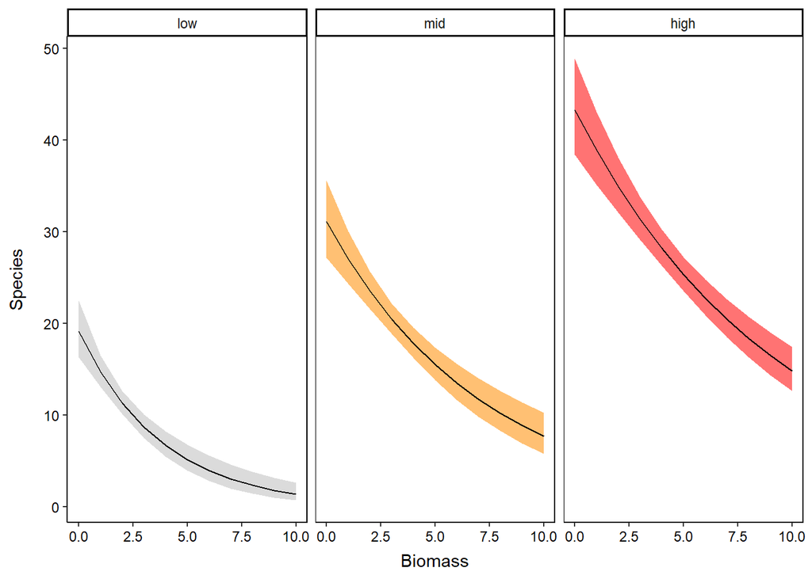

```r
# plot
ggplot2::ggplot(data = dplyr::filter(preds.spp), aes(x = x, y = predicted)) +
  geom_ribbon(aes(ymin = conf.low, ymax = conf.high, fill = group, alpha = 0.5)) +
  scale_fill_manual(values = c("grey", "darkorange", "red")) +
  geom_line(aes(y = predicted)) +
  labs(x = "Biomass",
       y = "Species") +
  facet_wrap(~group)
```

Perhaps we have new biomass and pH categories, and we want to put this into our model to predict species number. Here’s how you can do that, using our third GLM (**plant.glm.3**). Below, we create a new data frame with the biomass values and pH categories we want to use to predict the species number. We’ll predict for biomass = 20 at pH “mid”, and biomass = 25 at pH = “high”:

```r
# create data frame with biomass and pH values of interest
new.data = data.frame(Biomass = c(20, 25), pH = c("mid", "high"))
# make the prediction, using the third GLM we created
# type = "response" makes sure that our predicted values are on the original scale (number of species),
# not on the log scale (used in a Poisson GLM)
predicted_species = predict(plant.glm.3, newdata = new.data, type = "response")

print(predicted_species)
```

```
## [1] 1.927502 2.973914
```

Here, we see that a biomass of 20 at pH “mid” yields ~2 species, and a biomass of 25 at pH “high” yields ~3 species.

# **Practice exercise 1**

The data set **pollinator_abundance_data.csv** contains pollinator abundances on three different flower species, across three seasons (summer, autumn, and winter). Run the appropriate GLM on this data, and have a look at whether:

1. abundance differs across the three flower hosts
2. abundance differs across seasons
3. season affects abundance differently across the three flower species

Additionally, answer the following:

1. What is the response variable?
2. What is the predictor variable?
3. Do we need to include an interaction term in this model?
4. Which GLM family is appropriate for this data? Provide the relevant model diagnostic plots. (5) Provide box-and-whisker plots to graphically present the data

# **Practice exercise 2**

# **Practice exercise 3**

Use the `cheese` dataset in the `GLMsData` package to find out what makes a winning Cheddar cheese! The data comes from Moore and McCabe (1993).

Find out whether acetic acid, H2S, or lactic acid has an effect on taste scores by running a Gaussian GLM. Does the model fit well? Which ingredient/s had a significant effect on scores?

# **Practice exercise 4**

Use the `deposit` dataset in the `GLMsData` package to analyse the effect of three different insecticides at different dosages on insect mortality. Which insecticide, at which dosage, was the most effective? What type of GLM is best to use here?

Submit your answers to me at **clarke.vansteenderen@ru.ac.za** if you would like feedback.